# Expression pattern of genes requlating the onset, progression, and termination of neurogenesis

## 배경

이번 Brain span dataset을 이용하여 확인하고자 하는 것은 neurodevelopment 과정에서 나타나는 발현 양상의 변화이다. 특히 neurogenesis 단계에 집중하여 이 단계를 개시하고, 진행하며 종료하는 key factor들의 발현 양상을 집중적으로 살펴보고자 한다.  
Neural tube에서 cortex가 형성될 때 우선 분화되는 세포는 Neuroepithelial progenitor cell이다. 이 cell은 종방향으로 길게 뻗어 cortex의 Expansion된다. 이후 이 cell은 radial gila로 분화되는데, 이 세포에서 분열해 나온 세포들은 neuron으로 분화한다. 이 단계가 Neurogenesis 단계이다. 이후 radial glia는 astrogenesis 단계에 돌입하는데, 여때 radial glia에서 분열해 나온 세포는 astrocyte가 된다. 이 과정은 모두 하나의 세포에서 진행된다. Expasion, Neuron, Astrocyte가 모두 하나의 세포를 기원으로 하고 있다. 이는 한 세포의 Expression 양상이 바뀌면서 그 성격이 달라지기 때문이다. 따라서 Expression pattern의 변화를 확인할 수 있을 것이다.  
이 분석의 Reference는 Ben Martynoga, Daniela Drechsel, Francois Guillemot의 “Molecular Control of Neurogenesis: A View from the Mammalian Cerebral Cortex” 라는 리뷰 논문이다.

[figure not shown]

Figure1

이 논문을 바탕으로 확인할 유전자는 다음과 같다.  
Onset : PAX6 NEUROG2 (Ngn2) ASCL1  
Progression : MYCN (Myc)  
Termination : JAK2 STAT3 NFIA (NF1A)

## 데이터셋 확인

우선 데이터를 로드해주자. 데이터셋에 존재하는 세 data frame을 각각 임시 data frame으로 옮긴다.

```r
load('data_brainspan_DFC.20190928.Rdata')
# install.packages("ggsci") #한번만 install하고 삭제.
library("ggsci")
library("tidyverse")
#write.csv(s, file="s.csv",row.names=TRUE)

colnames(e)
exp <- e
colnames(g)
gen <- g
colnames(s)
sam <- s
```

해야할 것은 다음과 같다.  
1. age를 week로 정렬한다.  
2. 세 Data Frame을 통합한다.

#### 1. age를 모두 week로 정렬한다.

```r
sam <- mutate(sam, age_num = gsub("[a-z, ]","", age))
sam <- mutate(sam, age_char = gsub("[0-9, ]","", age))
sam <- mutate(sam, age_week = age_num)
sam$age_week <- as.numeric(sam$age_week)

for(i in 1 : 35){
 if(sam$age_char[i] == "mos")
  sam$age_week[i] <- sam$age_week[i] * 4 +38
 if(sam$age_char[i] == "yrs")
  sam$age_week[i] <- sam$age_week[i] * 52 + 38
}
select(sam, age, age_num, age_char, age_week)
```

#### 2. 세 D.F를 통합한다.

우선 exp에 gene 이름을 gen의 symbol로 추가한다. Column을 time(week) gene1 gene2… 순으로 만들어주어야 한다. 지금은 Column에 sample들이 위차한다.  
우선 row와 column을 뒤집어줄 필요가 있다. 그 후 total data frame을 만든다.

```r
tot <- data.frame(t(exp[-1]))
colnames(tot) <- exp[, 1]
tot <- tot %>% mutate(age_week = sam$age_week)
```

통합데이터가 완성되었다. 이제 골라내서 확인만하면 된다.

## Plotting

각 gene의 ENSEMBL code는 다음과 같다.  
PAX6 ENSG00000007372  
NEUROG2 ENSG00000178403  
ASCL1 ENSG00000139352  
MYCN ENSG00000134323  
JAK2 ENSG00000096968  
STAT3 ENSG00000168610  
NFIA ENSG00000162599  
공식적인 gene의 이름은 좌측과 같지만, plot에서는 논문에서 사용했던 이름을 사용한다. 특히 Jak2와 Stat3는 논문에서 Jak/stat로 나온다. 이는 Jak/Stat pathway에 Jak, Stat gene family가 다수 관여하기 때문인데, Neurodevelopment에 직접적으로 관여하는 것으로 관찰된 것은 Jak2와 Stat3이다.  
이들의 발현량과 나이, stage만 포함하는 Data Frame인 Data of interest, DOI를 만들자.

```r
doi <- tot %>% select(ENSG00000007372, ENSG00000178403, ENSG00000139352, ENSG00000134323, ENSG00000096968, ENSG00000168610, ENSG00000162599, age_week)
```

38주 동안의 발현을 확인해보자.  
onset level부터 확인한다.

```r
p <- doi %>% filter(age_week <= 55) %>%
  ggplot(aes(x = age_week, y = value, color = variable)) +
  geom_point(aes(y = ENSG00000007372, col = "Pax6"), size = 0.3, alpha = 0.2) +
  stat_smooth(aes(y = ENSG00000007372, col = "Pax6", linetype = "Onset"), size=0.4, method = "loess", level = 0.9, fullrange = TRUE, se = FALSE, span = 2/3, na.rm = TRUE) +
  geom_point(aes(y = ENSG00000178403, col = "Ngn2"), size = 0.3, alpha = 0.2) +
  stat_smooth(aes(y = ENSG00000178403, col = "Ngn2", linetype = "Onset"), size=0.4, method = "loess", level = 0.9, fullrange = TRUE, se = FALSE, span = 2/3, na.rm = TRUE) +
  geom_point(aes(y = ENSG00000139352, col = "Ascl1"), size = 0.3, alpha = 0.2) +
  stat_smooth(aes(y = ENSG00000139352, col = "Ascl1", linetype = "Onset"), size=0.4, method = "loess", level = 0.9, fullrange = TRUE, se = FALSE, span = 2/3, na.rm = TRUE) +
    geom_point(aes(y = ENSG00000134323, col = "Myc"), size = 0.3, alpha = 0.2) +
  stat_smooth(aes(y = ENSG00000134323, col = "Myc", linetype = "Progression"), size=0.7, method = "loess", level = 0.9, fullrange = TRUE, se = FALSE, span = 2/3, na.rm = TRUE) +
    geom_point(aes(y = ENSG00000096968, col = "Jak"), size = 0.3, alpha = 0.2) +
  stat_smooth(aes(y = ENSG00000096968, col = "Jak", linetype = "Termination"), size=1.2, method = "loess", level = 0.9, fullrange = TRUE, se = FALSE, span = 2/3, na.rm = TRUE) +
    geom_point(aes(y = ENSG00000168610, col = "Stat"), size = 0.3, alpha = 0.2) +
  stat_smooth(aes(y = ENSG00000168610, col = "Stat", linetype = "Termination"), size=1, method = "loess", level = 0.9, fullrange = TRUE, se = FALSE, span = 2/3, na.rm = TRUE) +
    geom_point(aes(y = ENSG00000162599, col = "Nf1a"), size = 0.3, alpha = 0.2) +
  stat_smooth(aes(y = ENSG00000162599, col = "Nf1a", linetype = "Termination"), size=1, method = "loess", level = 0.9, fullrange = TRUE, se = FALSE, span = 2/3, na.rm = TRUE)
p
```

stage를 표시하는 점선을 그리고 stage를 표시한다.

```r
p <- p +
  #geom_vline(xintercept = 7.5, color = "grey1", linetype="dashed", size = 0.2) +
  geom_vline(xintercept = 9.5, color = "grey1", linetype="dashed", size = 0.2) +
  geom_vline(xintercept = 12.5, color = "grey1", linetype="dashed", size = 0.2) +
  geom_vline(xintercept = 15.5, color = "grey1", linetype="dashed", size = 0.2) +
  geom_vline(xintercept = 18.5, color = "grey1", linetype="dashed", size = 0.2) +
  geom_vline(xintercept = 24.5, color = "grey1", linetype="dashed", size = 0.2) +
  geom_vline(xintercept = 39, color = "grey1", linetype="dashed", size = 0.2) +
  annotate("text", x = 8.5, y = 77, label = "S2A", size = 3, color = "gray10" ) +
  annotate("text", x = 11, y = 77, label = "S2B", size = 3, color = "gray10" ) +
  annotate("text", x = 14, y = 77, label = "S3A", size = 3, color = "gray10" ) +
  annotate("text", x = 17, y = 77, label = "S3B", size = 3, color = "gray10" ) +
  annotate("text", x = 21.5, y = 77, label = "S4", size = 3, color = "gray10" ) +
  annotate("text", x = 31.75, y = 77, label = "S5", size = 3, color = "gray10" ) +
  annotate("text", x = 39, y = 77, label = "Birth", size = 4, color = "Black" )+
  coord_cartesian(xlim = c(8, 40), ylim = c(0, 80))
p
```

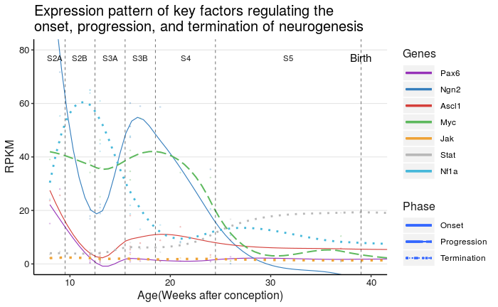

```r
p <- p +
  scale_color_locuszoom(name = "Genes", breaks=c("Pax6","Ngn2","Ascl1","Myc","Jak","Stat","Nf1a")) +
  scale_linetype_manual(name = "Phase", values = c("solid", "longdash", "dotted")) +
  xlab("Age(Weeks after conception)") +
  ylab("RPKM") +
  ggtitle("Expression pattern of key factors regulating the \nonset, progression, and termination of neurogenesis")+
  theme(panel.background = element_blank(),
        panel.grid.major.y = element_line(size = 0.4, linetype = "solid",color = "gray90"),
        panel.grid.major.x = element_blank(),
        plot.title = element_text(color = "Black", size = 15),
        legend.key.width = unit(1.2, "cm"),
        legend.title = element_text(color = "gray10", size = 12),
        axis.line = element_line(size = 0.5, linetype = "solid", color = "black"),
        axis.text = element_text(color = "gray10", size = 10),
        axis.title = element_text(color = "gray10", size = 12))
p
```

Plot이 완성되었다! 이제 plot을 출력한다.

```r
ggsave('plot.BrainSpan_Expression_pattern_in_Neurogenesis.pdf', p, width = 16, height = 9)
```

Assignment2 : 피드백으로 달라진 점  
우선 불필요한 코드나 데이터 프레임을 삭제하고 필요한 코드만 남겨놓았습니다. 그리고 코멘트에서 두번 지적받은 일부 유전자가 그래프 구분이 안된다는 점을 해결하기 위해 색 팔레트와 두께를 조절했습니다.